# Peer Assessment 1

Mark Konakov

### 1. Loading and preprocessing the data

```r
# Set working directory
setwd("./RR_Peer_Assessment_1")
library(dplyr)
library(ggplot2)
```

```r
# Download and unzip data
url <- "https://d396qusza40orc.cloudfront.net/repdata%2Fdata%2Factivity.zip"
download.file(url, destfile="./Activity_data.zip",method="curl")
unzip("Activity_data.zip",exdir="./")

# Load data
data <- read.csv("activity.csv")

# Transform data
date <- as.Date(data$date)
data <- select(data,-2)
activity_data <- mutate(data,date)
```

### 2. What is mean total number of steps taken per day

1. Calculate the total number of steps taken per day

```r
data_1 <-na.omit(activity_data)
data_2 <-group_by(data_1,date)
data_2 <- summarise(data_2,steps=sum(steps))
```

2. Make a histogram of the total number of steps taken each day

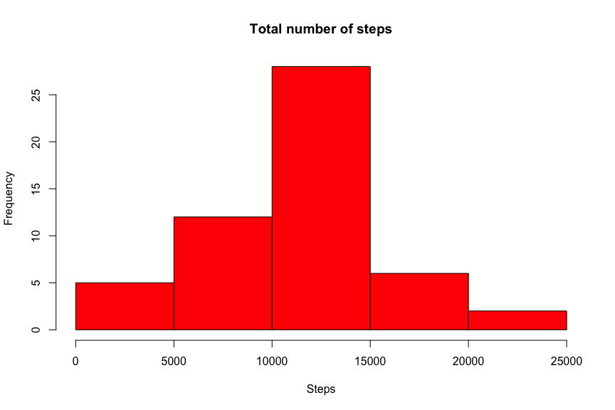

```r
hist(data_2$steps, xlab="Steps", main="Total number of steps", col="red")
```

3. Calculate and report the mean and median of the total number of steps taken per day

```r
data_3 <- summarise(data_2,steps=mean(steps))
data_4 <- summarise(data_2,steps=median(steps))
report_1 <-cbind(data_3,data_4)
names(report_1) <-c("mean","median")
report_1
```

```
##       mean median
## 1 10766.19  10765
```

### What is the average daily activity pattern

1. Time series plot of the 5-minute interval (x-axis) and the average number of steps taken, averaged across all days (y-axis)

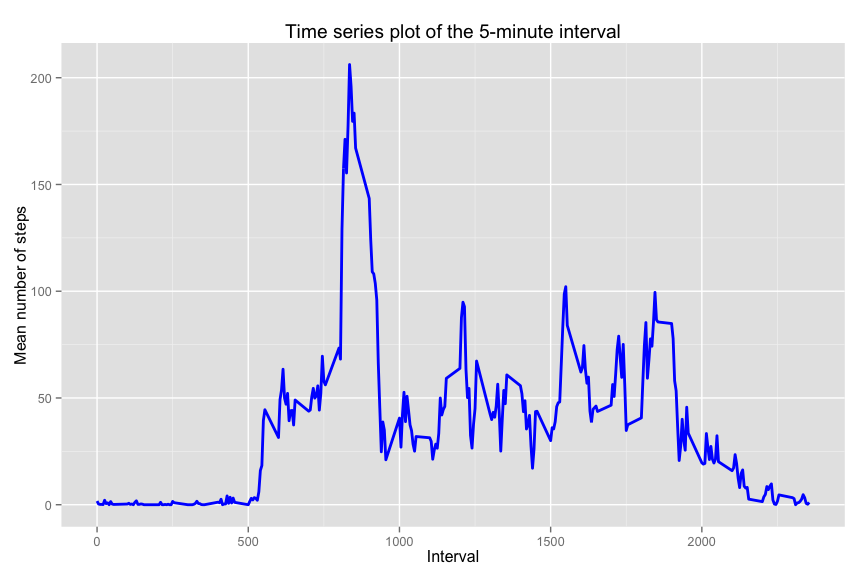

```r
data_5 <- group_by(data_1,interval)
data_5 <- summarise(data_5,steps=mean(steps))
plot <- ggplot(data_5, aes(interval,steps))+geom_line(color="blue",size=1)+labs(x="Interval",y="Mean number of steps",title="Time series plot of the 5-minute interval")
plot
```

2. 5-minute interval, on average across all the days in the dataset, contains the maximum number of steps

```r
report_2 <-data_5[data_5$steps==max(data_5$steps),]
report_2
```

```
## Source: local data frame [1 x 2]
##
##   interval    steps
## 1      835 206.1698
```